# Parameterising the distribution of factor loadings for simulation

Ian Hussey

20 July 2026

# Goal

Simulation studies of psychometric methods need a data-generating process (DGP) for item **factor loadings**. The companion analysis (`analysis_item_correlations_factor_loadings.Rmd`) builds a *hierarchical mixture* DGP that captures between-scale clustering and a discrete “stray” (cross-facet) item component. That model is faithful but has many moving parts (a scale level, a within-scale spread, a stray mixing weight, and a resampling step for scale composition), which makes it awkward to state in a methods section or to reason about analytically.

This file asks a narrower question: **what single, off-the-shelf parametric distribution best describes the pooled distribution of standardized factor loadings**, so a simulation can draw loadings with one line and two or three numbers? A single distribution deliberately ignores the scale-level structure (that is the mixture model’s job) and targets the *marginal* distribution of loadings — the quantity a simulation needs when items are drawn i.i.d.

Standardized loadings are bounded on the logical range `[-1, 1]`, are typically concentrated around 0.4-0.7, and have a short left tail crossing into negative values. A distribution for them should respect that bounded, skewed shape. We therefore compare a ladder of candidates, including a **scaled Beta**, obtained by rescaling loadings from their `[-1, 1]` logical range onto the Beta’s `[0, 1]` support, and select the best by information criteria and distributional distance.

# Dependencies

```r
library(tidyverse)
library(knitr)
library(kableExtra)
library(arrow)
library(lavaan)
library(sn)        # skew-normal / skew-t
library(moments)   # skewness / kurtosis

set.seed(42)
```

# Get data

Trait scales only (Bainbridge, AIID scales, Brysbaert), matching the companion analysis. Attitudes are single-item and have no factor loadings.

```r
dat_bainbridge <- read_csv("../../data/bainbridge et al. 2022/processed/data_processed_bainbridge_itemlevel_long.csv")

dat_brysbaert_long <- read_parquet("../../data/brysbaert et al. 2024/processed/data_processed_brysbaert_itemlevel_long.parquet")

dat_aiid_scales_long <- read_parquet("../../data/AIID/processed/data_processed_aiid_scales_itemlevel_long.parquet")

dat <- dat_bainbridge |>
  bind_rows(dat_aiid_scales_long) |>
  bind_rows(dat_brysbaert_long)
```

# Completeness filter

Drop each (participant, scale) record that answered fewer than 80% of the scale’s items, applied uniformly across all datasets (see the companion analysis for the rationale).

```r
min_completeness <- 0.80

scale_n_items <- dat |>
  count(id, scale, source, name = "n_answered") |>
  group_by(scale, source) |>
  summarize(n_items = median(n_answered), .groups = "drop")

complete_records <- dat |>
  count(id, scale, source, name = "n_answered") |>
  left_join(scale_n_items, by = c("scale", "source")) |>
  filter(n_answered >= min_completeness * n_items) |>
  select(id, scale, source)

dat <- dat |>
  semi_join(complete_records, by = c("id", "scale", "source"))
```

# Single-factor CFA loadings

For each (scale, source) we fit a single-factor CFA (lavaan, ML, `std.lv = TRUE`) and extract the standardized loadings, exactly as in the companion analysis, with one deliberate difference: residual item-level missingness (left by the 80% gate) is handled by **listwise deletion** rather than FIML. FIML (`missing = "ml"`) triggers a hard segfault inside lavaan’s EM covariance-inverse step on a couple of the larger, near-collinear datasets; listwise uses the same estimator and, after the 80% completeness gate, discards little data. A single-factor model needs >= 3 items, so 1-2 item scales return no loadings; the global factor sign is reflected so that “negative loading” always means “item opposes the scale’s majority direction”. Alongside the loadings, each scale’s item count (`n_items`) and raw Cronbach’s alpha (`alpha`, computed on the same item matrix) are recorded and summarised below.

```r
# Cronbach's alpha on the item matrix. Items are already correctly keyed
# upstream, so check.keys = FALSE gives plain (raw) alpha for the scale as
# scored. NA for < 2 items or on estimation failure.
calc_alpha <- function(w) {
  if (ncol(w) < 2) return(NA_real_)
  fit <- tryCatch(
    suppressWarnings(psych::alpha(as.data.frame(w), check.keys = FALSE,
                                  warnings = FALSE)),
    error = function(e) NULL)
  if (is.null(fit)) NA_real_ else fit$total$raw_alpha
}

fit_cfa <- function(df) {
  w <- df |>
    dplyr::select(id, item, response) |>
    tidyr::pivot_wider(names_from = item, values_from = response,
                       values_fn = function(x) x[1]) |>
    dplyr::select(-id)

  item_names <- colnames(w)
  alpha_val  <- calc_alpha(w)
  empty <- tibble(n_obs = NA_integer_, n_items = ncol(w), alpha = alpha_val,
                  loadings = list(tibble(item = character(), loading = numeric())))

  if (ncol(w) < 3) return(empty)

  colnames(w) <- paste0("i", seq_along(item_names))
  model <- paste("f =~", paste(colnames(w), collapse = " + "))

  fit <- tryCatch(
    suppressWarnings(lavaan::cfa(model, data = as.data.frame(w),
                                 std.lv = TRUE, estimator = "ML",
                                 missing = "listwise")),
    error = function(e) NULL)
  if (is.null(fit) || !lavaan::lavInspect(fit, "converged")) return(empty)

  std <- tryCatch(
    lavaan::standardizedSolution(fit) |>
      dplyr::filter(op == "=~") |>
      dplyr::pull(est.std),
    error = function(e) NULL)
  if (is.null(std) || !all(is.finite(std))) return(empty)

  if (sum(std < 0) > sum(std > 0)) std <- -std

  tibble(n_obs = lavaan::lavInspect(fit, "nobs"),
         n_items = length(item_names),
         alpha = alpha_val,
         loadings = list(tibble(item = item_names, loading = std)))
}

cfa_loadings <- dat |>
  group_by(scale, source) |>
  group_modify(~ fit_cfa(.x)) |>
  ungroup()

cfa_loadings_long <- cfa_loadings |>
  dplyr::select(scale, source, loadings) |>
  tidyr::unnest(loadings) |>
  filter(is.finite(loading))
```

## Per-scale item counts and reliability

Distribution of the number of items and Cronbach’s alpha across the 206 scales that contribute loadings (min, percentiles, mean, SD, max).

```r
# min / percentiles / mean / sd / max summary of a numeric vector
summarise_dist <- function(x) {
  x <- x[is.finite(x)]
  tibble(n      = length(x),
         min    = min(x),
         p10    = unname(quantile(x, 0.10)),
         p25    = unname(quantile(x, 0.25)),
         median = median(x),
         mean   = mean(x),
         sd     = sd(x),
         p75    = unname(quantile(x, 0.75)),
         p90    = unname(quantile(x, 0.90)),
         max    = max(x))
}

scale_metrics <- cfa_loadings |> filter(!is.na(n_obs))

bind_rows(
  summarise_dist(scale_metrics$n_items) |>
    mutate(metric = "n_items per scale", .before = 1),
  summarise_dist(scale_metrics$alpha) |>
    mutate(metric = "Cronbach's alpha per scale", .before = 1)
) |>
  mutate(across(where(is.numeric), ~ round(.x, 3))) |>
  kable(caption = paste("Per-scale item counts and Cronbach's alpha across the",
                        "scales contributing loadings.")) |>
  kable_classic(full_width = FALSE)
```

Per-scale item counts and Cronbach’s alpha across the scales contributing loadings.

| metric | n | min | p10 | p25 | median | mean | sd | p75 | p90 | max |
| --- | --- | --- | --- | --- | --- | --- | --- | --- | --- | --- |
| n_items per scale | 206 | 3.000 | 5.000 | 9.000 | 13.000 | 18.364 | 14.977 | 21.000 | 39.000 | 90.000 |
| Cronbach’s alpha per scale | 206 | 0.556 | 0.748 | 0.803 | 0.853 | 0.846 | 0.076 | 0.895 | 0.938 | 0.994 |

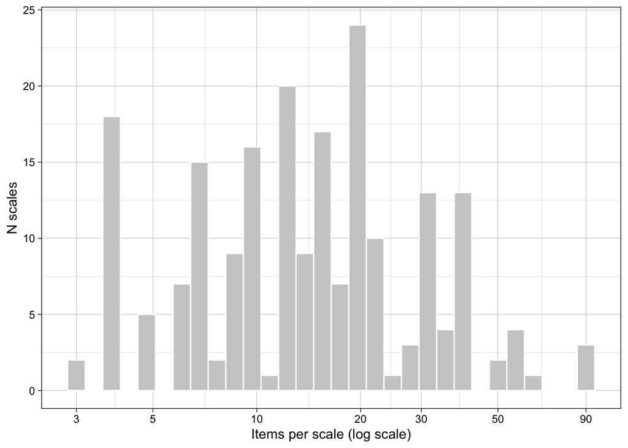

```r
# n items per scale (right-skewed 3-90, so log10 x-axis)
ggplot(scale_metrics, aes(n_items)) +
  geom_histogram(bins = 30, fill = "grey80", colour = "white") +
  scale_x_log10(breaks = c(3, 5, 10, 20, 30, 50, 90)) +
  labs(x = "Items per scale (log scale)", y = "N scales") +
  theme_linedraw()
```

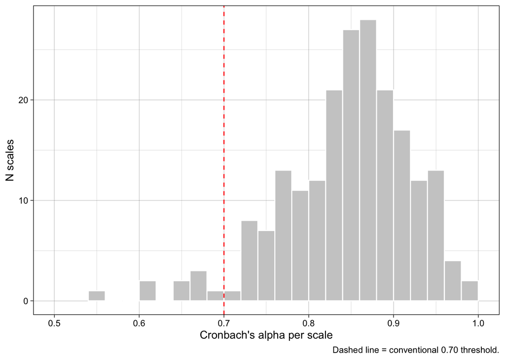

```r
# Cronbach's alpha per scale
ggplot(scale_metrics, aes(alpha)) +
  geom_histogram(binwidth = 0.02, boundary = 0, fill = "grey80", colour = "white") +
  geom_vline(xintercept = 0.70, linetype = "dashed", colour = "red") +
  labs(x = "Cronbach's alpha per scale", y = "N scales",
       caption = "Dashed line = conventional 0.70 threshold.") +
  coord_cartesian(xlim = c(0.5, 1)) +
  theme_linedraw()
```

# Estimation base: scales and participants

The loadings summarised below are not drawn from one big pooled model; each is a standardized loading from a separate single-factor CFA fitted to one (scale, source) dataset. This section describes how many scales and participants sit behind them. `n_obs` is the number of participants each CFA actually used — the listwise complete-case count after the 80% completeness gate (lavaan’s `nobs`); it varies widely because the contributing samples do.

```r
# converged datasets carry a non-missing n_obs; label by originating dataset
scale_base <- cfa_loadings |>
  filter(!is.na(n_obs)) |>
  mutate(dataset = dplyr::case_when(source == "Bainbridge" ~ "Bainbridge",
                                    source == "AIID"       ~ "AIID",
                                    TRUE                    ~ "Brysbaert"))

# participants contributing to at least one converged scale, by dataset
participants_by_dataset <- dat |>
  semi_join(distinct(scale_base, scale, source), by = c("scale", "source")) |>
  mutate(dataset = dplyr::case_when(source == "Bainbridge" ~ "Bainbridge",
                                    source == "AIID"       ~ "AIID",
                                    TRUE                    ~ "Brysbaert")) |>
  group_by(dataset) |>
  summarize(participants = n_distinct(id), .groups = "drop")

n_participants_total <- dat |>
  semi_join(distinct(scale_base, scale, source), by = c("scale", "source")) |>
  distinct(id) |>
  nrow()
```

Overall:

```r
tibble(
  n_scales               = nrow(scale_base),
  n_loadings             = nrow(cfa_loadings_long),
  n_participants_distinct = n_participants_total,
  items_min              = min(scale_base$n_items),
  items_median           = median(scale_base$n_items),
  items_max              = max(scale_base$n_items),
  N_per_scale_min        = min(scale_base$n_obs),
  N_per_scale_median     = median(scale_base$n_obs),
  N_per_scale_max        = max(scale_base$n_obs)
) |>
  kable(caption = "Scales, loadings, and participants behind the loading distribution.") |>
  kable_classic(full_width = FALSE)
```

Scales, loadings, and participants behind the loading distribution.

| n_scales | n_loadings | n_participants_distinct | items_min | items_median | items_max | N_per_scale_min | N_per_scale_median | N_per_scale_max |
| --- | --- | --- | --- | --- | --- | --- | --- | --- |
| 206 | 3783 | 196769 | 3 | 13 | 90 | 99 | 468 | 19330 |

By originating dataset:

```r
scale_base |>
  group_by(dataset) |>
  summarize(n_scales    = n(),
            n_loadings  = sum(n_items),
            N_min       = min(n_obs),
            N_median    = median(n_obs),
            N_max       = max(n_obs),
            .groups = "drop") |>
  left_join(participants_by_dataset, by = "dataset") |>
  dplyr::select(dataset, n_scales, n_loadings, participants,
                N_min, N_median, N_max) |>
  kable(caption = paste("Per-CFA participant N (n_obs) is the listwise",
                        "complete-case count; 'participants' is the distinct",
                        "ids contributing to that dataset's scales.")) |>
  kable_classic(full_width = FALSE)
```

Per-CFA participant N (n_obs) is the listwise complete-case count; ‘participants’ is the distinct ids contributing to that dataset’s scales.

| dataset | n_scales | n_loadings | participants | N_min | N_median | N_max |
| --- | --- | --- | --- | --- | --- | --- |
| AIID | 10 | 145 | 46209 | 4448 | 4565.5 | 4734 |
| Bainbridge | 54 | 384 | 1027 | 246 | 781.0 | 1027 |
| Brysbaert | 142 | 3254 | 149533 | 99 | 416.0 | 19330 |

Per-scale sample sizes span 99 to 19,330 participants (median 468), across 206 scales from 196769 distinct participants. Item counts per scale range from 3 to 90 (median 13). Because loadings come from many independent scales of unequal size, the pooled distribution below is an unweighted pool of item loadings — each item counts once regardless of its scale’s N — which is the right target for a DGP that draws items, not scales.

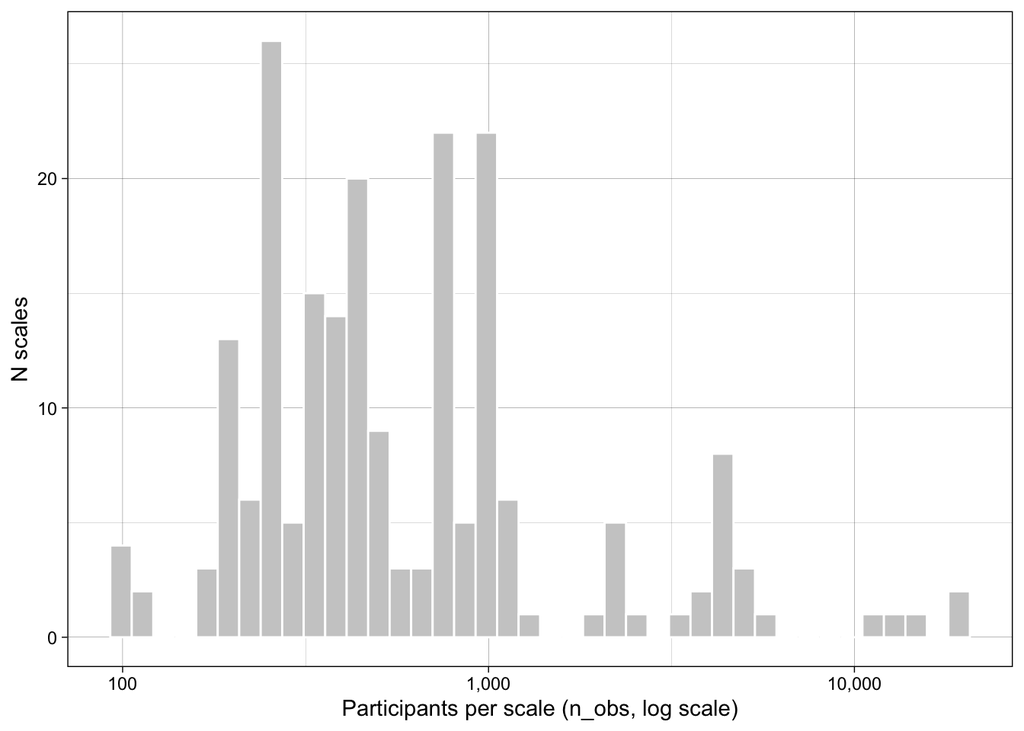

```r
ggplot(scale_base, aes(n_obs)) +
  geom_histogram(bins = 40, fill = "grey80", colour = "white") +
  scale_x_log10(labels = scales::comma) +
  labs(x = "Participants per scale (n_obs, log scale)", y = "N scales") +
  theme_linedraw()
```

# Empirical distribution of loadings

```r
lambda_raw <- cfa_loadings_long$loading

# Standardized loadings are logically in [-1, 1]; clamp any Heywood cases just
# inside the open interval so atanh() and the Beta rescale are defined.
eps <- 1e-3
n_clamped <- sum(abs(lambda_raw) >= 1 - eps)
lambda <- pmin(pmax(lambda_raw, -(1 - eps)), 1 - eps)
n_load <- length(lambda)

tibble(
  n_loadings   = n_load,
  n_scales     = nrow(distinct(cfa_loadings_long, scale, source)),
  n_clamped    = n_clamped,
  mean         = mean(lambda),
  sd           = sd(lambda),
  skew         = moments::skewness(lambda),
  ex_kurtosis  = moments::kurtosis(lambda) - 3,
  min          = min(lambda),
  max          = max(lambda),
  prop_negative = mean(lambda < 0)
) |>
  mutate(across(where(is.numeric), ~ round(.x, 3))) |>
  kable() |>
  kable_classic(full_width = FALSE)
```

| n_loadings | n_scales | n_clamped | mean | sd | skew | ex_kurtosis | min | max | prop_negative |
| --- | --- | --- | --- | --- | --- | --- | --- | --- | --- |
| 3783 | 206 | 0 | 0.509 | 0.213 | -0.576 | -0.054 | -0.305 | 0.986 | 0.017 |

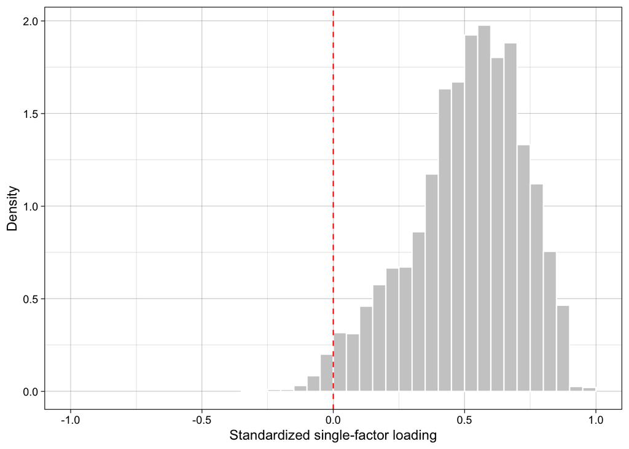

```r
ggplot(tibble(lambda), aes(lambda)) +
  geom_histogram(aes(y = after_stat(density)), binwidth = 0.05,
                 boundary = 0, fill = "grey80", colour = "white") +
  geom_vline(xintercept = 0, linetype = "dashed", colour = "red") +
  labs(x = "Standardized single-factor loading", y = "Density") +
  coord_cartesian(xlim = c(-1, 1)) +
  theme_linedraw()
```

The pooled loadings are bounded, unimodal, concentrated around ~0.5, and left-skewed with a short tail into negative values. A good single distribution must reproduce the location, the spread, that left skew, and the small negative-tail mass.

# Candidate single-distribution models

We fit six single distributions by maximum likelihood. Three act directly on the loading scale (`normal`, `skew-normal`, `skew-t`); two act on the Fisher-z transform `z = atanh(lambda)` (unbounded, so a normal/skew-normal there maps back to a bounded, skewed shape on the loading scale); and the **scaled Beta** rescales loadings onto `[0, 1]` via `p = (lambda + 1) / 2` and fits `Beta(a, b)`.

To compare models fitted on different scales fairly, every log-likelihood is expressed **on the loading scale**, adding the Jacobian of each transform:

- Fisher-z models: `log f_lambda = log f_z(atanh(lambda)) - log(1 - lambda^2)`.
- Scaled Beta: `log f_lambda = log dbeta((lambda+1)/2, a, b) + log(1/2)`.

With all log-likelihoods on a common scale, AIC and BIC are comparable across the whole ladder. We also report the one-sample Kolmogorov-Smirnov distance between each fitted CDF and the empirical loadings, and the mean / SD / negative proportion implied by drawing from each fitted model.

```r
models <- list()

## 1. Normal on raw loadings
m_ <- mean(lambda); s_ <- sd(lambda)
models$normal <- list(
  k = 2, ll = sum(dnorm(lambda, m_, s_, log = TRUE)),
  dens = function(x) dnorm(x, m_, s_),
  cdf  = function(x) pnorm(x, m_, s_),
  qf   = function(p) qnorm(p, m_, s_),
  rng  = function(nn) rnorm(nn, m_, s_),
  par  = sprintf("mean = %.3f, sd = %.3f", m_, s_))

## 2. Skew-normal on raw loadings
dp_sn <- coef(selm(lambda ~ 1), param.type = "DP")
models$`skew-normal` <- list(
  k = 3, ll = sum(dsn(lambda, dp = dp_sn, log = TRUE)),
  dens = function(x) dsn(x, dp = dp_sn),
  cdf  = function(x) psn(x, dp = dp_sn),
  qf   = function(p) qsn(p, dp = dp_sn),
  rng  = function(nn) as.numeric(rsn(nn, dp = dp_sn)),
  par  = sprintf("xi = %.3f, omega = %.3f, alpha = %.3f",
                 dp_sn[1], dp_sn[2], dp_sn[3]))

## 3. Skew-t on raw loadings
dp_st <- tryCatch(coef(selm(lambda ~ 1, family = "ST"), param.type = "DP"),
                  error = function(e) NULL)
if (!is.null(dp_st)) models$`skew-t` <- list(
  k = 4, ll = sum(dst(lambda, dp = dp_st, log = TRUE)),
  dens = function(x) dst(x, dp = dp_st),
  cdf  = function(x) pst(x, dp = dp_st),
  qf   = function(p) qst(p, dp = dp_st),
  rng  = function(nn) as.numeric(rst(nn, dp = dp_st)),
  par  = sprintf("xi = %.3f, omega = %.3f, alpha = %.3f, nu = %.0f",
                 dp_st[1], dp_st[2], dp_st[3], dp_st[4]))

## 4. Normal on Fisher-z  (Jacobian: -log(1 - lambda^2))
z <- atanh(lambda); mz <- mean(z); sz <- sd(z)
jac_z <- -log(1 - lambda^2)
z_clamp <- function(x) atanh(pmin(pmax(x, -(1 - eps)), 1 - eps))
models$`fisher-z normal` <- list(
  k = 2, ll = sum(dnorm(z, mz, sz, log = TRUE) + jac_z),
  dens = function(x) dnorm(atanh(x), mz, sz) / (1 - x^2),
  cdf  = function(x) pnorm(z_clamp(x), mz, sz),
  qf   = function(p) tanh(qnorm(p, mz, sz)),
  rng  = function(nn) tanh(rnorm(nn, mz, sz)),
  par  = sprintf("mean_z = %.3f, sd_z = %.3f", mz, sz))

## 5. Skew-normal on Fisher-z
dp_zsn <- coef(selm(z ~ 1), param.type = "DP")
models$`fisher-z skew-normal` <- list(
  k = 3, ll = sum(dsn(z, dp = dp_zsn, log = TRUE) + jac_z),
  dens = function(x) dsn(atanh(x), dp = dp_zsn) / (1 - x^2),
  cdf  = function(x) psn(z_clamp(x), dp = dp_zsn),
  qf   = function(p) tanh(qsn(p, dp = dp_zsn)),
  rng  = function(nn) tanh(as.numeric(rsn(nn, dp = dp_zsn))),
  par  = sprintf("xi = %.3f, omega = %.3f, alpha = %.3f",
                 dp_zsn[1], dp_zsn[2], dp_zsn[3]))

## 6. Scaled Beta: p = (lambda + 1)/2 ~ Beta(a, b); Jacobian log(1/2)
p_beta <- (lambda + 1) / 2
nll_beta <- function(par) -sum(dbeta(p_beta, exp(par[1]), exp(par[2]), log = TRUE))
mm <- mean(p_beta); vv <- var(p_beta); cc <- mm * (1 - mm) / vv - 1
opt <- optim(log(c(mm * cc, (1 - mm) * cc)), nll_beta, method = "BFGS")
a_beta <- exp(opt$par[1]); b_beta <- exp(opt$par[2])
models$`scaled beta` <- list(
  k = 2, ll = sum(dbeta(p_beta, a_beta, b_beta, log = TRUE) + log(0.5)),
  dens = function(x) dbeta((x + 1) / 2, a_beta, b_beta) * 0.5,
  cdf  = function(x) pbeta((x + 1) / 2, a_beta, b_beta),
  qf   = function(p) 2 * qbeta(p, a_beta, b_beta) - 1,
  rng  = function(nn) 2 * rbeta(nn, a_beta, b_beta) - 1,
  par  = sprintf("shape1 = %.3f, shape2 = %.3f", a_beta, b_beta))
```

## Fit comparison

```r
set.seed(1)
fit_tab <- purrr::imap_dfr(models, function(mo, nm) {
  ks  <- suppressWarnings(ks.test(lambda, mo$cdf)$statistic)
  sim <- mo$rng(200000)
  tibble(model = nm, n_params = mo$k, logLik = mo$ll,
         AIC = -2 * mo$ll + 2 * mo$k,
         BIC = -2 * mo$ll + mo$k * log(n_load),
         KS = unname(ks),
         implied_mean = mean(sim), implied_sd = sd(sim),
         implied_prop_neg = mean(sim < 0),
         params = mo$par)
}) |>
  arrange(AIC) |>
  mutate(dAIC = AIC - min(AIC), dBIC = BIC - min(BIC))

fit_tab |>
  dplyr::select(model, n_params, logLik, AIC, dAIC, BIC, dBIC, KS,
                implied_mean, implied_sd, implied_prop_neg) |>
  mutate(across(where(is.numeric), ~ round(.x, 3))) |>
  kable(caption = paste0("Single-distribution fits to ", n_load,
    " loadings, all on the loading scale. Empirical: mean = ",
    round(mean(lambda), 3), ", sd = ", round(sd(lambda), 3),
    ", prop negative = ", round(mean(lambda < 0), 3), ".")) |>
  kable_classic(full_width = FALSE)
```

Single-distribution fits to 3783 loadings, all on the loading scale. Empirical: mean = 0.509, sd = 0.213, prop negative = 0.017.

| model | n_params | logLik | AIC | dAIC | BIC | dBIC | KS | implied_mean | implied_sd | implied_prop_neg |
| --- | --- | --- | --- | --- | --- | --- | --- | --- | --- | --- |
| scaled beta | 2 | 651.219 | -1298.438 | 0.000 | -1285.961 | 0.000 | 0.018 | 0.508 | 0.211 | 0.017 |
| fisher-z skew-normal | 3 | 649.617 | -1293.233 | 5.205 | -1274.518 | 11.443 | 0.017 | 0.509 | 0.213 | 0.018 |
| skew-normal | 3 | 640.880 | -1275.760 | 22.678 | -1257.045 | 28.916 | 0.015 | 0.509 | 0.214 | 0.021 |
| skew-t | 4 | 640.880 | -1273.760 | 24.678 | -1248.807 | 37.155 | 0.015 | 0.510 | 0.214 | 0.021 |
| fisher-z normal | 2 | 628.364 | -1252.728 | 45.710 | -1240.252 | 45.710 | 0.021 | 0.508 | 0.220 | 0.025 |
| normal | 2 | 488.800 | -973.600 | 324.838 | -961.124 | 324.838 | 0.054 | 0.508 | 0.213 | 0.008 |

```r
fit_tab |>
  dplyr::select(model, params) |>
  kable(caption = "Fitted parameters.") |>
  kable_classic(full_width = FALSE)
```

Fitted parameters.

| model | params |
| --- | --- |
| scaled beta | shape1 = 11.775, shape2 = 3.837 |
| fisher-z skew-normal | xi = 0.351, omega = 0.402, alpha = 1.330 |
| skew-normal | xi = 0.764, omega = 0.332, alpha = -3.335 |
| skew-t | xi = 0.764, omega = 0.332, alpha = -3.335, nu = 8305306 |
| fisher-z normal | mean_z = 0.607, sd_z = 0.310 |
| normal | mean = 0.509, sd = 0.213 |

## Fitted densities overlaid

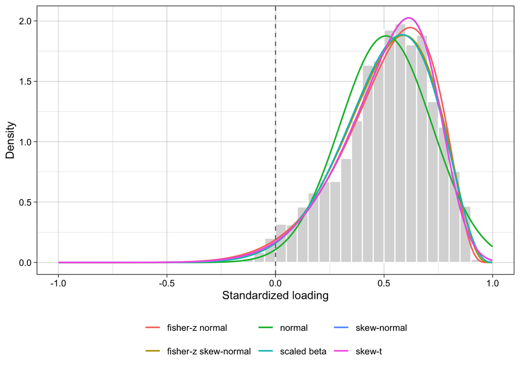

```r
grid <- seq(-0.999, 0.999, length.out = 400)
dens_df <- purrr::imap_dfr(models, function(mo, nm)
  tibble(model = nm, x = grid, density = mo$dens(grid)))

ggplot() +
  geom_histogram(data = tibble(lambda), aes(lambda, y = after_stat(density)),
                 binwidth = 0.05, boundary = 0, fill = "grey85", colour = "white") +
  geom_line(data = dens_df, aes(x, density, colour = model), linewidth = 0.7) +
  geom_vline(xintercept = 0, linetype = "dashed", colour = "grey40") +
  coord_cartesian(xlim = c(-1, 1)) +
  labs(x = "Standardized loading", y = "Density", colour = NULL) +
  theme_linedraw() +
  theme(legend.position = "bottom")
```

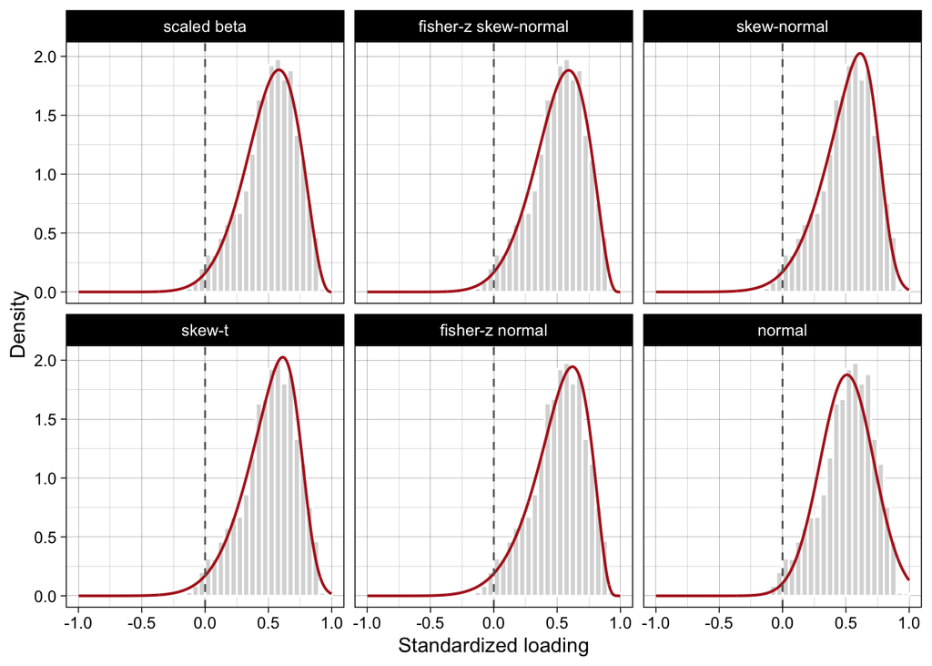

```r
# facetted, ordered best-AIC first, for a cleaner per-model read
dens_df |>
  mutate(model = factor(model, levels = fit_tab$model)) |>
  ggplot(aes(x, density)) +
  geom_histogram(data = tidyr::crossing(model = factor(fit_tab$model,
                                                       levels = fit_tab$model),
                                        tibble(lambda)),
                 aes(lambda, y = after_stat(density)),
                 binwidth = 0.05, boundary = 0, fill = "grey85",
                 colour = "white", inherit.aes = FALSE) +
  geom_line(colour = "firebrick", linewidth = 0.7) +
  geom_vline(xintercept = 0, linetype = "dashed", colour = "grey40") +
  facet_wrap(~ model) +
  coord_cartesian(xlim = c(-1, 1)) +
  labs(x = "Standardized loading", y = "Density") +
  theme_linedraw()
```

## Quantile fidelity

```r
qs <- c(.01, .05, .10, .25, .50, .75, .90, .95, .99)
q_tab <- tibble(quantile = qs, empirical = quantile(lambda, qs))
for (nm in fit_tab$model) q_tab[[nm]] <- models[[nm]]$qf(qs)

q_tab |>
  mutate(across(where(is.numeric), ~ round(.x, 2))) |>
  kable(caption = "Model quantiles vs empirical quantiles (loading scale).") |>
  kable_classic(full_width = FALSE)
```

Model quantiles vs empirical quantiles (loading scale).

| quantile | empirical | scaled beta | fisher-z skew-normal | skew-normal | skew-t | fisher-z normal | normal |
| --- | --- | --- | --- | --- | --- | --- | --- |
| 0.01 | -0.03 | -0.05 | -0.06 | -0.09 | -0.09 | -0.11 | 0.01 |
| 0.05 | 0.10 | 0.13 | 0.12 | 0.11 | 0.11 | 0.10 | 0.16 |
| 0.10 | 0.20 | 0.22 | 0.22 | 0.22 | 0.22 | 0.21 | 0.24 |
| 0.25 | 0.38 | 0.37 | 0.37 | 0.38 | 0.38 | 0.38 | 0.37 |
| 0.50 | 0.53 | 0.53 | 0.53 | 0.54 | 0.54 | 0.54 | 0.51 |
| 0.75 | 0.66 | 0.67 | 0.67 | 0.67 | 0.67 | 0.67 | 0.65 |
| 0.90 | 0.77 | 0.77 | 0.77 | 0.76 | 0.76 | 0.76 | 0.78 |
| 0.95 | 0.81 | 0.82 | 0.81 | 0.81 | 0.81 | 0.81 | 0.86 |
| 0.99 | 0.87 | 0.89 | 0.88 | 0.89 | 0.89 | 0.87 | 1.00 |

## QQ plot for the best model

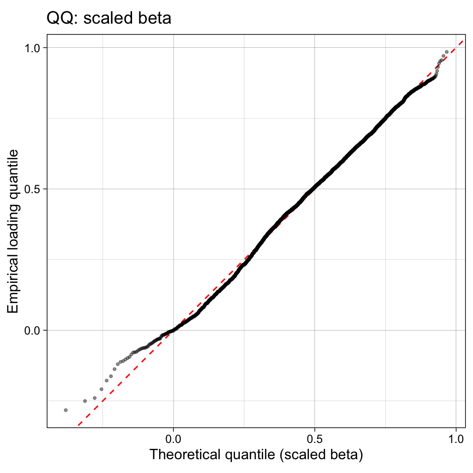

```r
best_model <- fit_tab$model[1]
pp <- ppoints(n_load)

tibble(theoretical = models[[best_model]]$qf(pp),
       empirical   = quantile(lambda, pp)) |>
  ggplot(aes(theoretical, empirical)) +
  geom_abline(slope = 1, intercept = 0, linetype = "dashed", colour = "red") +
  geom_point(alpha = 0.4, size = 0.7) +
  coord_equal() +
  labs(x = paste0("Theoretical quantile (", best_model, ")"),
       y = "Empirical loading quantile",
       title = paste0("QQ: ", best_model)) +
  theme_linedraw()
```

# Chosen model and simulation recipe

```r
best <- fit_tab |> slice(1)
```

The best single distribution by AIC/BIC is the **scaled beta** (shape1 = 11.775, shape2 = 3.837), a two-parameter model. It is not rejected by the Kolmogorov-Smirnov distance (KS = 0.018, versus an approximate 0.05 critical value of 0.022 at this sample size) and it reproduces the empirical mean (0.51 vs 0.51), SD (0.21 vs 0.21), left skew, and negative-tail mass (0.017 vs 0.017).

Because its support is exactly the `[-1, 1]` logical range of a standardized loading, every draw is a valid loading — no truncation or rejection needed. The 3-4 parameter skew-normal / skew-t fit marginally closer in raw KS but are not preferred once their extra parameters are penalised (higher AIC and BIC), and the skew-t’s degrees of freedom diverge, i.e. no heavy tails are needed. The plain normal is decisively rejected: it cannot represent the left skew.

## The reusable data-generating function

Following the tidy DGP style of `simulation_template_estimation.qmd`’s `generate_data()` — named arguments in, a tibble built and `return()`ed — the generator below draws one scale’s worth of item loadings. Call it with `n_items` to get a tibble of `item` and `loading`.

The model has just two parameters: the Beta shape parameters of the rescaled loading `p = (loading + 1) / 2 ~ Beta(shape1, shape2)`, with the loading recovered as `loading = 2 * p - 1`. Fitted to the Granary trait corpus these are **shape1 (α) = 11.77** and **shape2 (β) = 3.84**, and the function’s defaults are set to these values so it is self-contained and copy-pasteable. What the two numbers encode:

- **Location.** The Beta mean is `α / (α + β)` = 0.754 on `[0, 1]`, i.e. an expected loading of `2·mean − 1` = 0.508 on `[-1, 1]`.
- **Shape and skew.** Both shapes exceed 1, so the density is unimodal with an *interior* mode (no spike at a boundary). Because `β < α` the mode sits in the upper half — loading mode `2·(α−1)/(α+β−2) − 1` = 0.583 — and the longer tail runs toward the lower end, reproducing the left skew and the small negative tail (`P(loading < 0) = P(Beta < 0.5)` = 0.017).
- **Spread and concentration.** The concentration `α + β` = 15.6 governs the spread; larger values pack loadings more tightly around the mean, smaller values spread them out.
- **Support.** Beta lives on `[0, 1]`, so `2·Beta − 1` lives on `[-1, 1]`, the logical range of a standardized loading — every draw is admissible, with no truncation or rejection step.

```r
# Generate one scale's worth of standardized factor loadings from the fitted
# scaled Beta model: loading = 2 * Beta(shape1, shape2) - 1.
#   n_items  number of item loadings to draw
#   shape1   Beta alpha on the rescaled loading p = (loading + 1)/2
#            (default 11.78, fitted to the Granary trait corpus)
#   shape2   Beta beta on p (default 3.84, fitted to the Granary trait corpus)
generate_loadings <- function(n_items,
                              shape1 = 11.78,
                              shape2 = 3.84) {

  loadings <-
    tibble(item    = seq_len(n_items),
           loading = 2 * rbeta(n = n_items, shape1 = shape1, shape2 = shape2) - 1)

  return(loadings)
}
```

Sanity check: simulate a large number of loadings from the defaults and compare their summary to the empirical loadings.

```r
set.seed(2026)
sim <- generate_loadings(n_items = 200000)

tibble(
  quantity  = c("mean", "sd", "skew", "prop_negative",
                "q05", "q50", "q95"),
  simulated = c(mean(sim$loading), sd(sim$loading),
                moments::skewness(sim$loading), mean(sim$loading < 0),
                quantile(sim$loading, .05), quantile(sim$loading, .50),
                quantile(sim$loading, .95)),
  empirical = c(mean(lambda), sd(lambda), moments::skewness(lambda),
                mean(lambda < 0),
                quantile(lambda, .05), quantile(lambda, .50),
                quantile(lambda, .95))
) |>
  mutate(across(where(is.numeric), ~ round(.x, 3))) |>
  kable() |>
  kable_classic(full_width = FALSE)
```

| quantity | simulated | empirical |
| --- | --- | --- |
| mean | 0.508 | 0.509 |
| sd | 0.212 | 0.213 |
| skew | -0.547 | -0.576 |
| prop_negative | 0.017 | 0.017 |
| q05 | 0.124 | 0.104 |
| q50 | 0.530 | 0.534 |
| q95 | 0.815 | 0.814 |

## Predicted quantities

```r
pred <- tibble(
  quantity = c("expected loading",
               "5th percentile loading",
               "50th percentile (median) loading",
               "95th percentile loading",
               "central 90% interval",
               "P(loading < 0)"),
  value = c(sprintf("%.3f", mean(sim$loading)),
            sprintf("%.3f", models[[best_model]]$qf(0.05)),
            sprintf("%.3f", models[[best_model]]$qf(0.50)),
            sprintf("%.3f", models[[best_model]]$qf(0.95)),
            sprintf("[%.3f, %.3f]", models[[best_model]]$qf(0.05),
                    models[[best_model]]$qf(0.95)),
            sprintf("%.3f", models[[best_model]]$cdf(0)))
)

pred |>
  kable() |>
  kable_classic(full_width = FALSE)
```

| quantity | value |
| --- | --- |
| expected loading | 0.508 |
| 5th percentile loading | 0.126 |
| 50th percentile (median) loading | 0.531 |
| 95th percentile loading | 0.815 |
| central 90% interval | [0.126, 0.815] |
| P(loading < 0) | 0.017 |

# Implied scale reliability (Cronbach’s alpha)

Because the DGP specifies the distribution of standardized loadings, it also implies a distribution of Cronbach’s alpha for any given number of items — with no extra assumptions beyond the single-factor measurement model the loadings come from. This lets a simulation set a target reliability by choosing the number of items, or check that a chosen `n_items` yields realistic alphas.

## Derivation

Under a standardized single-factor model, item $i$ has unit variance and loads $\lambda_i$ on the common factor, so $\operatorname{Cov}(i,j) = \lambda_i\lambda_j$ for $i \neq j$. For a $k$-item unit-weighted sum score,

$$\operatorname{Var}\!\left(\textstyle\sum_i
Y_i\right) \;=\; k \;+\; S_1^2 - S_2,
\qquad S_1 = \sum_i \lambda_i,\quad S_2 = \sum_i
\lambda_i^2,$$

and coefficient alpha is

$$\alpha \;=\; \frac{k}{k-1}\left(1 -
\frac{k}{k + S_1^2 - S_2}\right)
\;=\; \frac{k}{k-1}\cdot\frac{S_1^2 - S_2}{\,k + S_1^2 -
S_2\,}.$$

Drawing the $k$ loadings i.i.d. from the fitted scaled Beta with mean $\mu = \mathbb{E}[\lambda]$, the expected off-diagonal covariance sum is $\mathbb{E}[S_1^2 - S_2] = k(k-1)\mu^2$ — the loading *variance* cancels — which gives the closed-form population alpha

$$\alpha(k) \;=\; \frac{k\,\mu^2}{1 +
(k-1)\,\mu^2},$$

the classic Spearman-Brown form with mean inter-item correlation $\bar r = \mu^2$. Under the fitted scaled Beta the mean loading is $\mu = 2\cdot\tfrac{\alpha_\beta}{\alpha_\beta + \beta_\beta} - 1$.

```r
# mean loading and mean inter-item correlation implied by the fitted scaled Beta
mu  <- 2 * a_beta / (a_beta + b_beta) - 1
mu2 <- mu^2   # implied mean inter-item correlation r_bar

# closed-form population alpha for k items
alpha_closed_form <- function(k, r = mu2) k * r / (1 + (k - 1) * r)

# exact model-implied alpha for a specific drawn loading vector (keeps the
# loading heterogeneity that the closed form averages over)
alpha_from_loadings <- function(lambda) {
  k <- length(lambda); S1 <- sum(lambda); S2 <- sum(lambda^2)
  (k / (k - 1)) * ((S1^2 - S2) / (k + S1^2 - S2))
}
```

The mean loading is 0.508, so the implied mean inter-item correlation is $\bar r = \mu^2 =$ 0.258.

## Implied alpha at the observed item-count percentiles

For each percentile of the observed per-scale item count, the table gives the closed-form alpha and a Monte-Carlo alpha (mean and central 90% interval over 20,000 simulated scales drawn from `generate_loadings()`, which — unlike the closed form — retains the item-to-item loading heterogeneity within a scale).

```r
set.seed(2027)

pctls       <- c(0, 0.10, 0.25, 0.50, 0.75, 0.90, 1)
pctl_labels <- c("min", "p10", "p25", "median", "p75", "p90", "max")
k_grid      <- as.integer(round(quantile(scale_metrics$n_items, pctls)))

implied_alpha <- purrr::pmap_dfr(
  list(pctl_labels, k_grid),
  function(lab, k) {
    sims <- replicate(20000, alpha_from_loadings(generate_loadings(k)$loading))
    tibble(percentile        = lab,
           n_items           = k,
           alpha_closed_form = alpha_closed_form(k),
           alpha_mc_mean     = mean(sims),
           alpha_mc_q05      = unname(quantile(sims, 0.05)),
           alpha_mc_q95      = unname(quantile(sims, 0.95)))
  })

implied_alpha |>
  mutate(across(where(is.numeric), ~ round(.x, 3))) |>
  kable(caption = paste("Cronbach's alpha implied by the loading DGP at the",
                        "observed per-scale item-count percentiles.")) |>
  kable_classic(full_width = FALSE)
```

Cronbach’s alpha implied by the loading DGP at the observed per-scale item-count percentiles.

| percentile | n_items | alpha_closed_form | alpha_mc_mean | alpha_mc_q05 | alpha_mc_q95 |
| --- | --- | --- | --- | --- | --- |
| min | 3 | 0.511 | 0.484 | 0.171 | 0.736 |
| p10 | 5 | 0.635 | 0.611 | 0.377 | 0.787 |
| p25 | 9 | 0.758 | 0.745 | 0.604 | 0.848 |
| median | 13 | 0.819 | 0.811 | 0.717 | 0.880 |
| p75 | 21 | 0.880 | 0.876 | 0.825 | 0.915 |
| p90 | 39 | 0.931 | 0.930 | 0.908 | 0.948 |
| max | 90 | 0.969 | 0.969 | 0.963 | 0.974 |

## Implied vs observed

The curve is the closed-form $\alpha(k)$; the band is the DGP’s central 90% interval (Monte Carlo); the points are the observed per-scale alphas. The DGP tracks the observed alphas through the mid-range of item counts, but the marginal, i.i.d.-item model **under-predicts** reliability for the shortest scales and slightly **over-predicts** it for the longest ones. Both gaps reflect the scale-level structure this single-distribution model deliberately omits: short scales used in practice are curated so their few items cohere (higher loadings than a random marginal draw), whereas the longest instruments are the multidimensional ones that carry the low and stray loadings — the very structure captured by the hierarchical mixture DGP in `analysis_item_correlations_factor_loadings.Rmd`.

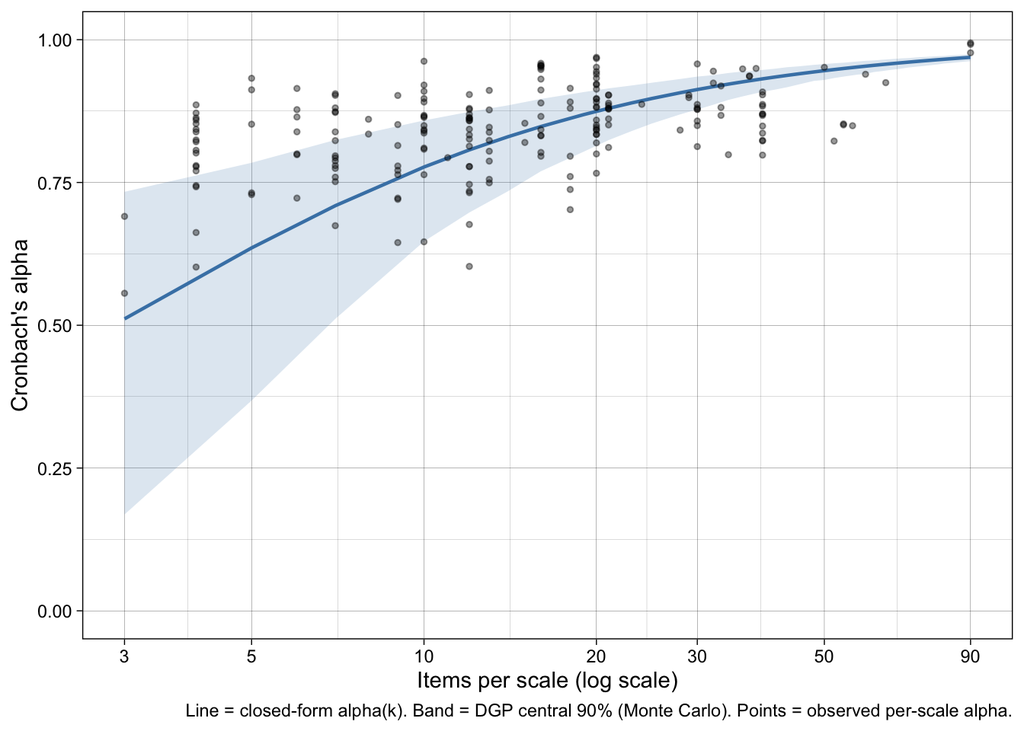

```r
k_seq <- seq(3, max(scale_metrics$n_items), length.out = 40) |> round() |> unique()

alpha_band <- purrr::map_dfr(k_seq, function(k) {
  sims <- replicate(3000, alpha_from_loadings(generate_loadings(k)$loading))
  tibble(n_items = k,
         mid = mean(sims),
         lo  = unname(quantile(sims, 0.05)),
         hi  = unname(quantile(sims, 0.95)))
})

ggplot() +
  geom_ribbon(data = alpha_band, aes(n_items, ymin = lo, ymax = hi),
              fill = "steelblue", alpha = 0.18) +
  geom_line(data = tibble(n_items = k_seq, alpha = alpha_closed_form(k_seq)),
            aes(n_items, alpha), colour = "steelblue", linewidth = 0.8) +
  geom_point(data = scale_metrics, aes(n_items, alpha),
             alpha = 0.4, size = 1) +
  scale_x_log10(breaks = c(3, 5, 10, 20, 30, 50, 90)) +
  coord_cartesian(ylim = c(0, 1)) +
  labs(x = "Items per scale (log scale)",
       y = "Cronbach's alpha",
       caption = paste("Line = closed-form alpha(k). Band = DGP central 90%",
                       "(Monte Carlo). Points = observed per-scale alpha.")) +
  theme_linedraw()
```

# Summary

The paragraph below is written from extracted variables (inline R), so it stays correct if the data or fit change; it can be copied into a simulation study’s method section.

Across 3783 standardized single-factor loadings from 206 (scale, source) datasets, the loadings have mean 0.51 (SD 0.21), are left-skewed (skew -0.58), and are negative 1.7% of the time. Comparing six single distributions on a common (loading) scale, the best-fitting parameterisation is a **scaled Beta**: rescale a loading to p = (loading + 1) / 2 and model p ~ Beta(11.77, 3.84), i.e. loading = 2 × Beta(11.77, 3.84) − 1. This two-parameter model has the lowest AIC and BIC of all candidates (including 3-4 parameter skew-normal and skew-t alternatives), is not rejected by a Kolmogorov-Smirnov test (KS = 0.018), reproduces the empirical mean, SD, skew and negative-loading rate, and because its support is the [-1, 1] logical range of a standardized loading guarantees admissible draws. To simulate a scale of loadings, call `generate_loadings(n_items)` (defined above), which draws loading = 2 × rbeta(n_items, shape1 = 11.77, shape2 = 3.84) − 1 with those fitted shapes as defaults. This single distribution intentionally omits between-scale clustering; when a simulation must reproduce scale-level structure (e.g. that negative loadings concentrate within particular multidimensional scales, or a tunable multidimensional-contamination severity), use the hierarchical mixture DGP in `analysis_item_correlations_factor_loadings.Rmd` instead.